# Analisis exploratorio de dataSet ‘House-Pricing’

## 6.5 DATE

La fecha presenta un formato que es necesario cambiar, se busca ver la relacion entre los distintos año/meses y el precio de las casas

```r
a_raw_data$date =  as.Date(a_raw_data$date, format = "%Y%m%dT000000")
df_fecha_form = a_raw_data %>% select(price,date)  %>% mutate(date_year = paste(year(date), month(date), sep="/"))
```

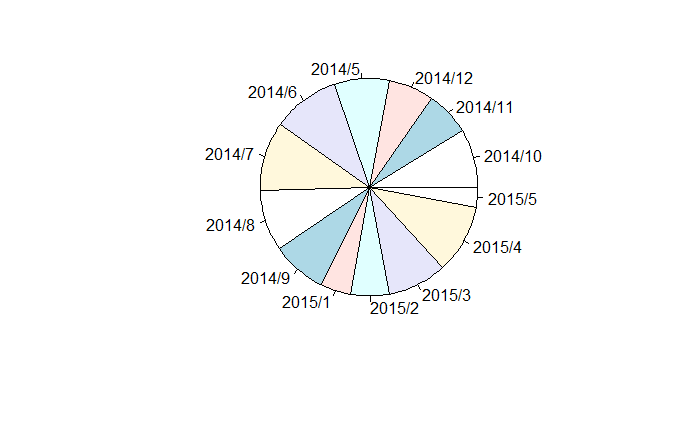

```r
pie(table(df_fecha_form$date_year))
```

Salvo casos particulares parece que la fecha de publicacion supongo, no afecta el precio de una casa.

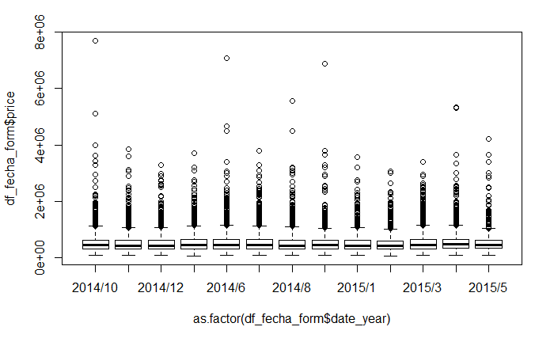

```r
plot(df_fecha_form$price ~ as.factor(df_fecha_form$date_year))
```

## 6.6 Antiguedad

```r
df_antiguedad= a_raw_data
df_antiguedad= mutate(df_antiguedad,antiguedad= ifelse(yr_renovated>0,
                                                      year(date)-yr_renovated,
                                                      year(date)-yr_built))
```

```r
par(mfrow = c(1,2))
boxplot(df_antiguedad$antiguedad)
summary(df_antiguedad$antiguedad)
```

```
   Min. 1st Qu.  Median    Mean 3rd Qu.    Max.
  -1.00   15.00   37.00   40.94   60.00  115.00
```

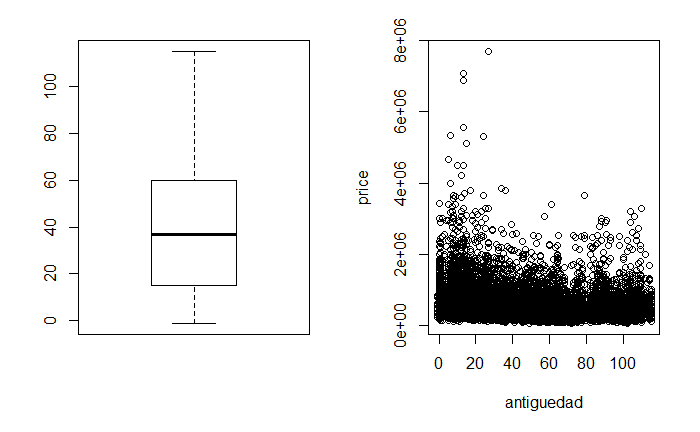

```r
plot(price~antiguedad,data=df_antiguedad)
```

## Regresion lineal con Atributo Antiguedad

```r
modelo_fecha<-lm(price ~ . -yr_renovated -yr_built -date , data=df_antiguedad)
summary(modelo_fecha)
```

```
Call:
lm(formula = price ~ . - yr_renovated - yr_built - date, data = df_antiguedad)

Residuals:
     Min       1Q   Median       3Q      Max
-1187530  -101797   -11303    76837  4523979

Coefficients: (1 not defined because of singularities)
                Estimate Std. Error t value Pr(>|t|)
(Intercept)   -8.306e+06  2.910e+06  -2.855  0.00431 **
bedrooms      -3.537e+04  1.924e+03 -18.389  < 2e-16 ***
bathrooms      3.644e+04  3.311e+03  11.005  < 2e-16 ***
sqft_living    1.598e+02  4.445e+00  35.945  < 2e-16 ***
sqft_lot       1.424e-01  4.873e-02   2.923  0.00347 **
floors         7.027e+02  3.657e+03   0.192  0.84760
waterfront     5.985e+05  1.763e+04  33.952  < 2e-16 ***
view           5.717e+04  2.170e+03  26.346  < 2e-16 ***
condition      2.685e+04  2.399e+03  11.192  < 2e-16 ***
grade          9.098e+04  2.184e+03  41.657  < 2e-16 ***
sqft_above     2.944e+01  4.435e+00   6.639 3.24e-11 ***
sqft_basement         NA         NA      NA       NA
zipcode       -5.368e+02  3.350e+01 -16.026  < 2e-16 ***
lat            6.220e+05  1.090e+04  57.092  < 2e-16 ***
long          -2.507e+05  1.329e+04 -18.861  < 2e-16 ***
sqft_living15  1.750e+01  3.505e+00   4.993 5.98e-07 ***
sqft_lot15    -3.746e-01  7.450e-02  -5.028 4.99e-07 ***
antiguedad     2.127e+03  7.277e+01  29.231  < 2e-16 ***
---
Signif. codes:  0 ‘***’ 0.001 ‘**’ 0.01 ‘*’ 0.05 ‘.’ 0.1 ‘ ’ 1

Residual standard error: 204600 on 21596 degrees of freedom
Multiple R-squared:  0.6895,    Adjusted R-squared:  0.6893
F-statistic:  2997 on 16 and 21596 DF,  p-value: < 2.2e-16
```

## 6.7 Dimensiones

En este caso en los plots y en la grafica de correlacion se puede deducir que entre sqft_living y sqft_above sqft_basement hay colinealidad. Y luego de ver el dataset notamos que living es la suma de las otras

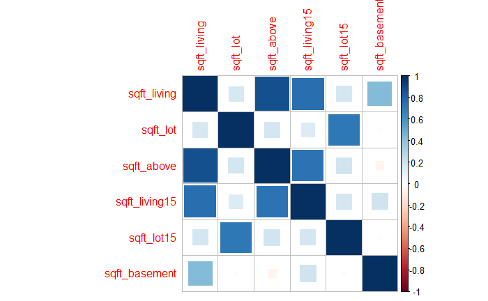

```r
prueba1 = a_raw_data
corrplot(cor(prueba1[,c("sqft_living","sqft_lot","sqft_above","sqft_living15","sqft_lot15","sqft_basement")]),method="square")
```

```r
modelo_dim1 <-lm(price~sqft_living+sqft_lot+sqft_above+sqft_living15+sqft_lot15+sqft_basement, data=prueba1)
summary(modelo_dim1)
```

```
Call:
lm(formula = price ~ sqft_living + sqft_lot + sqft_above + sqft_living15 +
    sqft_lot15 + sqft_basement, data = prueba1)

Residuals:
     Min       1Q   Median       3Q      Max
-1149859  -145451   -21100   106515  4569641

Coefficients: (1 not defined because of singularities)
                Estimate Std. Error t value Pr(>|t|)
(Intercept)   -1.006e+05  5.399e+03 -18.638  < 2e-16 ***
sqft_living    2.678e+02  4.250e+00  63.006  < 2e-16 ***
sqft_lot       8.136e-02  6.126e-02   1.328    0.184
sqft_above    -3.481e+01  4.534e+00  -7.679 1.67e-14 ***
sqft_living15  7.790e+01  4.031e+00  19.323  < 2e-16 ***
sqft_lot15    -7.845e-01  9.327e-02  -8.412  < 2e-16 ***
sqft_basement         NA         NA      NA       NA
---
Signif. codes:  0 ‘***’ 0.001 ‘**’ 0.01 ‘*’ 0.05 ‘.’ 0.1 ‘ ’ 1

Residual standard error: 258600 on 21607 degrees of freedom
Multiple R-squared:  0.5039,    Adjusted R-squared:  0.5038
F-statistic:  4390 on 5 and 21607 DF,  p-value: < 2.2e-16
```

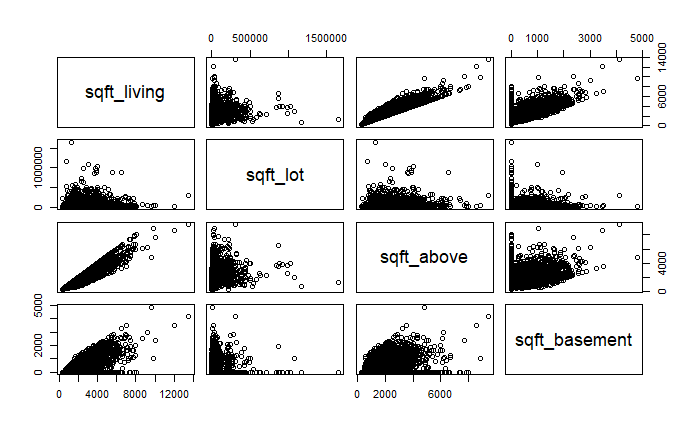

```r
#vif(modelo_dim1) Aca no uso esto por que me da error por que dice que hay collinealdiad perfecta que es la de basement y la de above con living

pair1= select(a_raw_data,sqft_living,sqft_lot,sqft_above,sqft_basement)
pairs(pair1)
```

```r
NA
NA
NA
NA
```

```r
imcdiag(select(prueba1, -c("price","date")), prueba1$price)
```

```
Call:
imcdiag(x = select(prueba1, -c("price", "date")), y = prueba1$price)


All Individual Multicollinearity Diagnostics Result

                 VIF    TOL        Wi        Fi Leamer    CVIF Klein
bedrooms      1.6521 0.6053  828.3123  880.1226 0.7780 -0.3199     0
bathrooms     3.3508 0.2984 2986.1980 3172.9823 0.5463 -0.6488     1
sqft_living      Inf 0.0000       Inf       Inf 0.0000    -Inf     1
sqft_lot      2.1025 0.4756 1400.5267 1488.1285 0.6897 -0.4071     0
floors        2.0119 0.4970 1285.4201 1365.8221 0.7050 -0.3895     0
waterfront    1.2038 0.8307  258.8428  275.0333 0.9114 -0.2331     0
view          1.4352 0.6968  552.7810  587.3570 0.8347 -0.2779     0
condition     1.2495 0.8003  316.9071  336.7294 0.8946 -0.2419     0
grade         3.4170 0.2927 3070.3592 3262.4077 0.5410 -0.6616     1
sqft_above       Inf 0.0000       Inf       Inf 0.0000    -Inf     1
sqft_basement    Inf 0.0000       Inf       Inf 0.0000    -Inf     1
yr_built      2.4306 0.4114 1817.3452 1931.0187 0.6414 -0.4706     0
yr_renovated  1.1506 0.8691  191.2482  203.2106 0.9323 -0.2228     0
zipcode       1.6622 0.6016  841.1561  893.7698 0.7756 -0.3218     0
lat           1.1806 0.8470  229.4530  243.8051 0.9203 -0.2286     0
long          1.8256 0.5478 1048.7283 1114.3254 0.7401 -0.3535     0
sqft_living15 2.9797 0.3356 2514.8175 2672.1173 0.5793 -0.5769     0
sqft_lot15    2.1357 0.4682 1442.6326 1532.8681 0.6843 -0.4135     0

1 --> COLLINEARITY is detected by the test
0 --> COLLINEARITY is not detected by the test

floors , coefficient(s) are non-significant may be due to multicollinearity

R-square of y on all x: 0.6997

* use method argument to check which regressors may be the reason of collinearity
===================================
```